# Estimating exponential growth via sporadic detection

Michael R. McLaren

Adam Howes

Abstract

**Background** Detecting exponential growth is a central goal of the Nucleic Acid Observatory (NAO). Regression using a Poisson generalised linear model (GLM) is possibly the simplest statistical approach to detecting exponential growth.

```r
knitr::opts_chunk$set(
  echo = TRUE,
  cache = TRUE,
  autodep = TRUE,
  cache.comments = FALSE
)

options(scipen = 999)

cbpalette <- multi.utils::cbpalette()
```

```r
library(tidyverse)
# ggplot helpers
# library(ggbeeswarm)
library(cowplot)
library(patchwork)
theme_set(theme_minimal())
# stats helpers
# library(broom)
```

Suppose that there is a local epidemic that is growing exponentially at some rate $r$, so that the total number of cases at time $t = 1, \ldots, T$ is
$$n_t = n_0 e^{rt}.$$

Meanwhile, cases are detected sporadically, in a manner that we can approximate by a Poisson process with intensity
$$\lambda_t = c_t n_t,$$
where $c_t$ is the detection rate at time $t$. For now we will assume that $c_t = c$ is a constant. Another way that $c$ could be interpreted is as the rate of travel through an international airport that is being monitored via a sentinel site, where we assume that all infections are detected.

Let $x_t$ be the number of detections at time $t$ and $X_t$ be the cumulative number of detections. The number of detections will most clearly appear to be growing exponentially once $\lambda_t \gg 1$. However, perhaps we can infer positive exponential growth long before this point using an appropriate statistical analysis that accounts for the sporadic (Poisson) nature of detections.

## First simulated example

```r
r <- 0.1
c <- 1e-4
T_days <- 125

set.seed(42)

sim <- tibble(t = seq(1, T_days)) %>%
  mutate(
    n = exp(r * t),
    lambda = c * n,
    x = rpois(n(), lambda),
    X = cumsum(x)
  )
```

We start by simulating exponentially increasing data with $r$ set to 0.1 and $c$ set to 0.0001. Note: the value of $c$ doesn’t change the dynamics other than to scale down $\lambda_t$, so we don’t need to test different values of $c$; similarly for $n_0$. The number of daily detections looks as follows:

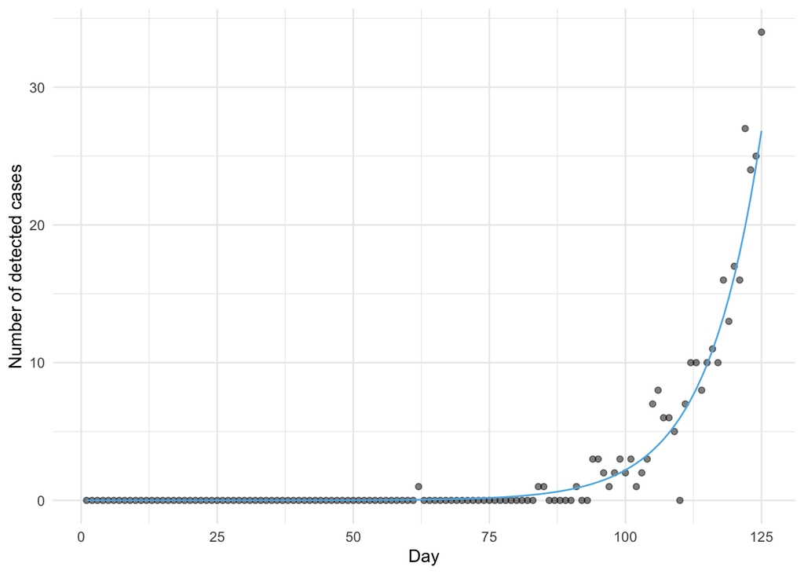

```r
p1 <- sim %>%
  ggplot(aes(t, x)) +
  geom_point(alpha = 0.5) +
  geom_line(aes(y = lambda), color = cbpalette[1]) +
  labs(x = "Day", y = "Number of detected cases")

p1
```

Note that the period of time where $\lambda \approx 1$ is very short. Though in some sense this is the nature of exponential data, if we instead had a much smaller $r$, this period would be longer. It might be helpful to look on the log scale:

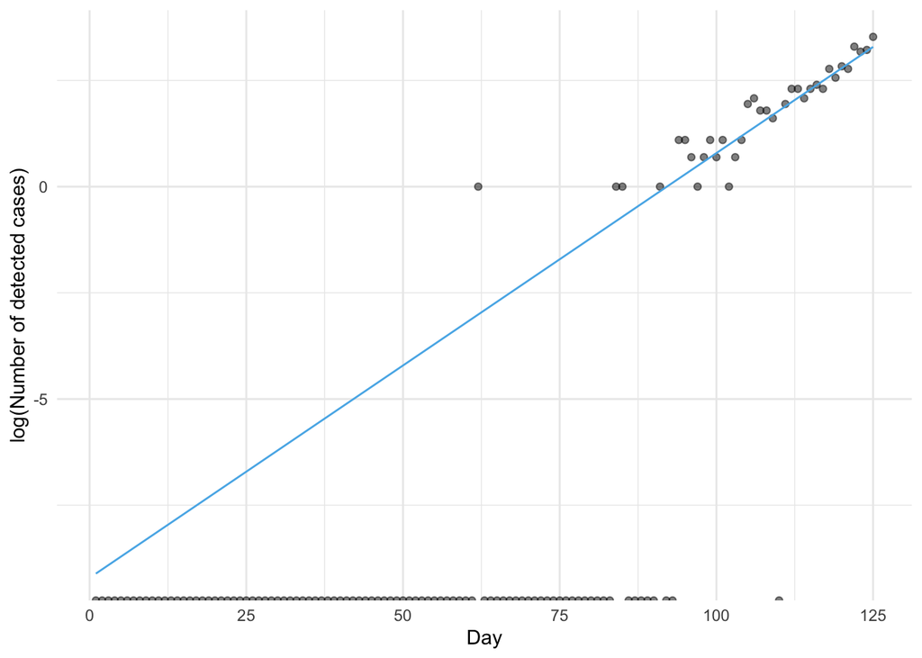

```r
p2 <- sim %>%
  ggplot(aes(t, log(x))) +
  geom_point(alpha = 0.5) +
  geom_line(aes(y = log(lambda)), color = cbpalette[1]) +
  labs(x = "Day", y = "log(Number of detected cases)")

p2
```

Taking this view allows us to more clearly see the challenge presented by Poisson observations. The logarithm of the latent Poisson intensity is increasing linearly, yet the logarithm of the number of cases only starts to look linear at around the hundredth day.

Let’s fit the data using a Poisson regression model of the form
$$x_t \sim \text{Poisson}(\lambda_t), \\
\log(\lambda_t) = \beta_0 + \beta t,$$
where $\beta_0$ is the intercept and $\beta$ is the slope of the linear predictor. This model is specified in `glm` using the formula `x ~ 1 + t` as follows:

```r
fit <- glm(x ~ 1 + t, family = poisson, data = sim)
coef(fit)
```

```
## (Intercept)           t
## -10.0816799   0.1080257
```

What about if it were day $s$ and we wanted to know if cases were increasing exponentially? In that case, we would only have some subset of the data, $x_1, \ldots, x_s$. We will try fitting the same GLM model as before, but just to this subset. Note, it isn’t possible to use `glm()` before there are any cases.

```r
first_detection <- sim %>% filter(x > 0) %>% slice(1) %>% pull(t)
```

As such, the first day we will consider is when the first detection happens, which is day 62.

```r
set.seed(42)

fits <- tibble(today = (first_detection + 1):T_days) %>%
  mutate(
    fit = map(today, ~glm(x ~ t, family = poisson, data = sim[seq(.x),])),
    fit = map(fit, broom::tidy, conf.int = TRUE)
  ) %>%
  unnest(fit)
```

What does our inference for $\beta_0$ and $\beta$ look like? Let’s add an indicator for whether the confidence interval is above zero:

```r
fits <- fits %>%
  mutate(above_zero = as.logical((conf.low > 0) & (conf.high > 0)))
```

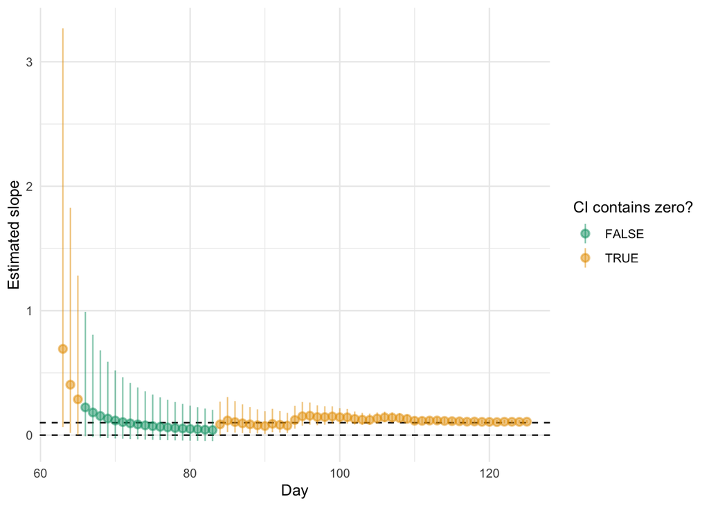

```r
p3 <- fits %>%
  filter(term == 't', today >= first_detection) %>%
  ggplot(aes(today, y = estimate, ymax = conf.high, ymin = conf.low, col = above_zero)) +
  geom_hline(yintercept = c(0, r), color = "black", linetype = "dashed") +
  geom_pointrange(alpha = 0.5) +
  scale_colour_manual(values = cbpalette[c(2, 3)]) +
  labs(x = "Day", y = "Estimated slope", col = "CI contains zero?")

p3
```

Interestingly, in this case, upon the first detection the 95% CI for $\beta$ is already above zero! After this date, it then quickly reverts back to including zero until a few weeks later.

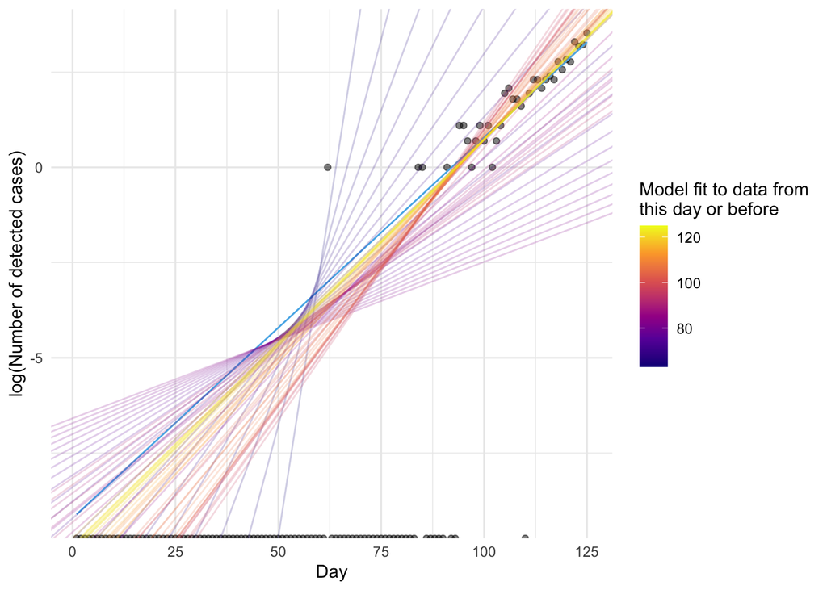

```r
fits_long <- fits %>%
  select(today, term, estimate) %>%
  pivot_wider(
    names_from = "term",
    values_from = "estimate"
  ) %>%
  rename(
    "intercept" = "(Intercept)"
  )

sim %>%
  ggplot(aes(t, log(x))) +
  geom_point(alpha = 0.5) +
  geom_line(aes(y = log(lambda)), color = cbpalette[1]) +
  geom_abline(data = fits_long, aes(intercept = intercept, slope = t, col = today), alpha = 0.2) +
  scale_colour_viridis_c(option = "C") +
  labs(x = "Day", y = "log(Number of detected cases)", col = "Model fit to data from\nthis day or before")
```

On the day that the first case is detected, the linear model (on the log scale) is able to (essentially) perfectly fit that single data point by putting the intercept as being very negative. In particular, the fitted regression model on day 63 is

```r
fits %>%
  filter(today == first_detection + 1)
```

| today | term | estimate | std.error | statistic | p.value | conf.low | conf.high | above_zero |
| --- | --- | --- | --- | --- | --- | --- | --- | --- |
| 63 | (Intercept) | -44.3614194 | 43.8494001 | -1.0116768 | 0.3116926 | -205.95312419 | -11.69082 | FALSE |
| 63 | t | 0.6931472 | 0.7070652 | 0.9803158 | 0.3269303 | 0.06470956 | 3.26851 | TRUE |

That this issue could be fixed by a Bayesian model which doesn’t perfectly interpolate the data (it would be regularlised using priors).

# A slower growing pandemic

```r
r <- 1e-2
c <- 1e-4
```

Let’s consider a slower growing pandemic with has a smaller growth rate $r$ of 0.01, and a low probability of detection $c$ of 0.0001.

```r
set.seed(42)

sim <- tibble(t = seq(1, 2000)) %>%
  mutate(
    n = exp(r * t),
    lambda = c * n,
    x = rpois(n(), lambda),
    X = cumsum(x)
  )
```

## Time to first detection

```r
first_detection <- sim %>% filter(x > 0) %>% slice(1) %>% pull(t) %>% print
```

```
## [1] 573
```

Under these assumptions, the time the first detection occurs is on day 573. What about more generally: what is the distribution over time to first detection $\psi$? We are interested in the probability at time $t$ at least one case has been observed $F_\psi(t) = \mathbb{P}(\psi \leq t) = \mathbb{P}(x_s > 0 \text{ for some } s \leq t)$. Recalling that $x_t \sim \text{Poisson}(\lambda_t)$, this can be calculated via
$$\mathbb{P}(x_s > 0 \text{ for some } s \leq t) = 1 - \mathbb{P}(x_s =
0 \text{ for all } s \leq t) \\
= 1 - \prod_{s \leq t} \mathbb{P}(x_s = 0) \\
= 1 - \prod_{s \leq t} \frac{{\lambda_t}^0}{0!} e^{-\lambda_s} \\
= 1 - \prod_{s \leq t} e^{-\lambda_s}, \\
= 1 - \exp\left( {- \sum_{s \leq t} \lambda_s} \right)$$

```r
compute_psi <- function(t, t0, c, n0, r) {
  day <- t0:t
  lambda_t <- c * n0 * exp(r * day)
  1 - exp(-sum(lambda_t))
}

compute_psi(1, 1, c = c, n0 = 1, r = r)
```

```
## [1] 0.0001009999
```

So, for example, the probability that a case is observed on day one, using this formula, is 0.000101. We can plot the probability that at least one case is observed by day as follows

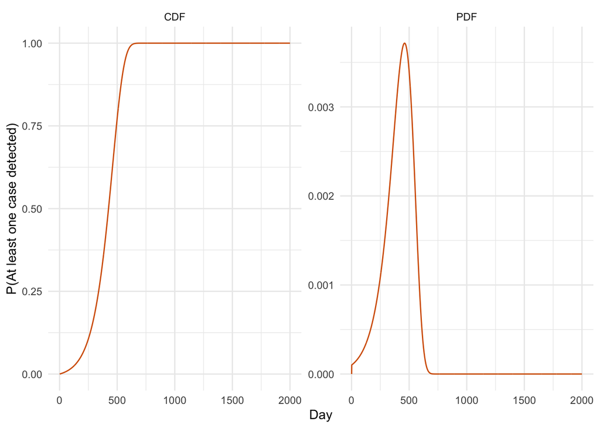

```r
psi <- tibble(t = seq(1, 2000)) %>%
  mutate(
    cdf = map_dbl(t, ~ compute_psi(.x, 1, c = c, n0 = 1, r = r)),
    pdf = c(0, diff(cdf))
  )

psi_long <- psi %>%
  pivot_longer(
    cols = c("pdf", "cdf"),
    names_to = "type",
    values_to = "value"
  )

psi_long %>%
  mutate(type = toupper(type)) %>%
  ggplot(aes(x = t, y = value)) +
    geom_line(col = cbpalette[6]) +
    facet_wrap(~type, scales = "free") +
    labs(x = "Day", y = "P(At least one case detected)") +
    theme_minimal()
```

So, by the looks of things, 573 is a quite typical draw from the distribution of time to first detection.

Using the fact that $\mathbb{E}(\psi) = \int_{-\infty}^0 F_\psi(t) \text{d} t + \int_0^\infty (1 - F_\psi(t)) \text{d} t$, where $F_\psi(\cdot)$ is the cumulative distribution function of $\psi$, we can compute the expected time to first detection as
$$\mathbb{E}(\psi) = \int_0^\infty (1 - F_\psi(t)) \text{d} t \\
= \sum_{t = 0}^\infty (1 - F_\psi(t)) \\
= \sum_{t = 0}^\infty 1 - \left( 1 - \exp\left( {- \sum_{s \leq t}
\lambda_s} \right) \right) \\
= \sum_{t = 0}^\infty \exp\left( {- \sum_{s \leq t} \lambda_s} \right)$$

Perhaps there is a smart way to compute this exactly, but it can be approximated by truncating to a finite sum of the first $N$ terms
$$\sum_{t = 0}^{N} \exp\left( {- \sum_{s \leq t} \lambda_s} \right)$$

Given that we know the PDF of $\psi$, it should be quite easy to choose an $N$ such that the approximation is accurate. Coding this up, we have

```r
#' Implicity N here is length(sim$lambda)
#' Looking at the CDF or PDF of psi, this should be sufficient
#' Given that the intensity is increasing exponentially, and the contribution to the expectation should only be linear
#' there is a good argument that including higher order terms would not change the computation very much
length(sim$lambda)
```

```
## [1] 2000
```

```r
lambda_cum <- cumsum(sim$lambda)
sum(exp(-lambda_cum))
```

```
## [1] 406.872
```

How do the factors $c$ and $r$ change the expected time to detection? Rewriting the expression for $\mathbb{E}(\psi)$ more explicitly
$$\mathbb{E}(\psi) = \sum_{t = 0}^\infty \exp\left( {- \sum_{s \leq t} c
\exp \left( -rs \right) } \right) \\
= \sum_{t = 0}^\infty \prod_{s \leq t} \exp\left({- c \exp \left( -rs
\right) } \right) \\$$
(I’ve not said anything useful about $c$ or $r$ here yet!)

To take another approach, let’s just plot the different CDF and PDF curves, varying $r$ and $c$:

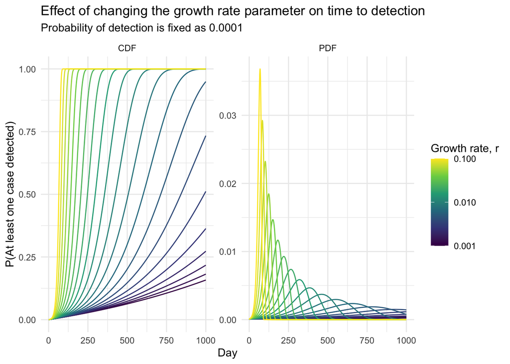

```r
r_seq <- 10^{seq(-3, -1, by = 0.1)}

psi_r <- expand_grid(t = 1:1000, r = r_seq) %>%
  group_by(r) %>%
  mutate(
    cdf = pmap_dbl(list(t, r), ~ compute_psi(.x, 1, c = c, n0 = 1, r = .y)),
    pdf = c(0, diff(cdf))
  )

psi_r_long <- psi_r %>%
  pivot_longer(
    cols = c("pdf", "cdf"),
    names_to = "type",
    values_to = "value"
  )

psi_r_long %>%
  mutate(type = toupper(type)) %>%
  ggplot(aes(x = t, y = value, col = r, group = r)) +
    geom_line() +
    scale_color_continuous(trans = "log10", type = "viridis") +
    facet_wrap(~type, scales = "free") +
    labs(title = "Effect of changing the growth rate parameter on time to detection",
         subtitle = paste0("Probability of detection is fixed as ", c),
         x = "Day", y = "P(At least one case detected)", col = "Growth rate, r") +
    theme_minimal()
```

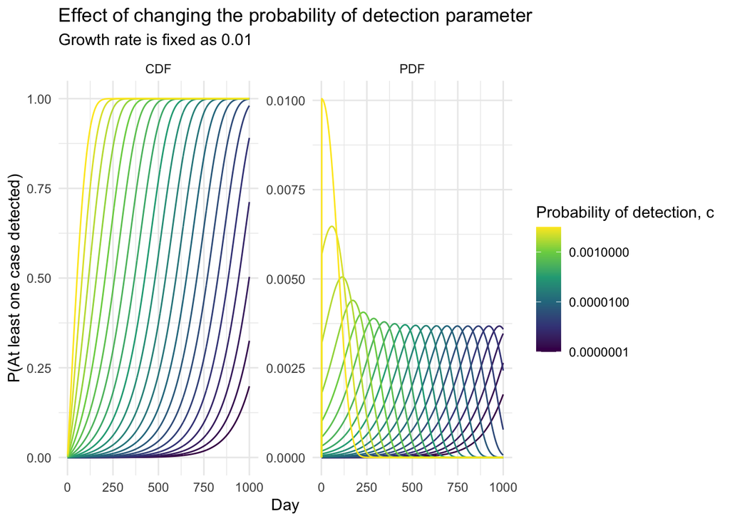

```r
c_seq <- 10^{seq(-7, -2, by = 0.25)}

psi_c <- expand_grid(t = 1:1000, c = c_seq) %>%
  group_by(c) %>%
  mutate(
    cdf = pmap_dbl(list(t, c), ~ compute_psi(.x, 1, c = .y, n0 = 1, r = r)),
    pdf = c(0, diff(cdf))
  )

psi_c_long <- psi_c %>%
  pivot_longer(
    cols = c("pdf", "cdf"),
    names_to = "type",
    values_to = "value"
  )

psi_c_long %>%
  mutate(type = toupper(type)) %>%
  ggplot(aes(x = t, y = value, col = c, group = c)) +
    geom_line() +
    scale_color_continuous(trans = "log10", type = "viridis") +
    facet_wrap(~type, scales = "free") +
    labs(title = "Effect of changing the probability of detection parameter",
         subtitle = paste0("Growth rate is fixed as ", r),
         x = "Day", y = "P(At least one case detected)", col = "Probability of detection, c") +
    theme_minimal()
```

So, it looks to me like changing the probability of detection on the $\log(10)$ scale results in linear scaling of the time to detection. Whereas, changes to the growth rate, again on the $\log(10)$ scale, result in more substantial coolings of the time to detection.

## Poisson modelling

Let’s fit the same model as before, to see about how quickly exponential growth can be detected in this instance. Again, we have to fit models starting from after the first detection has occurred due to the limitations of `glm`. The number of cases gets very large past day 1500, see figure below, so we will limit interest to $t < 1000$.

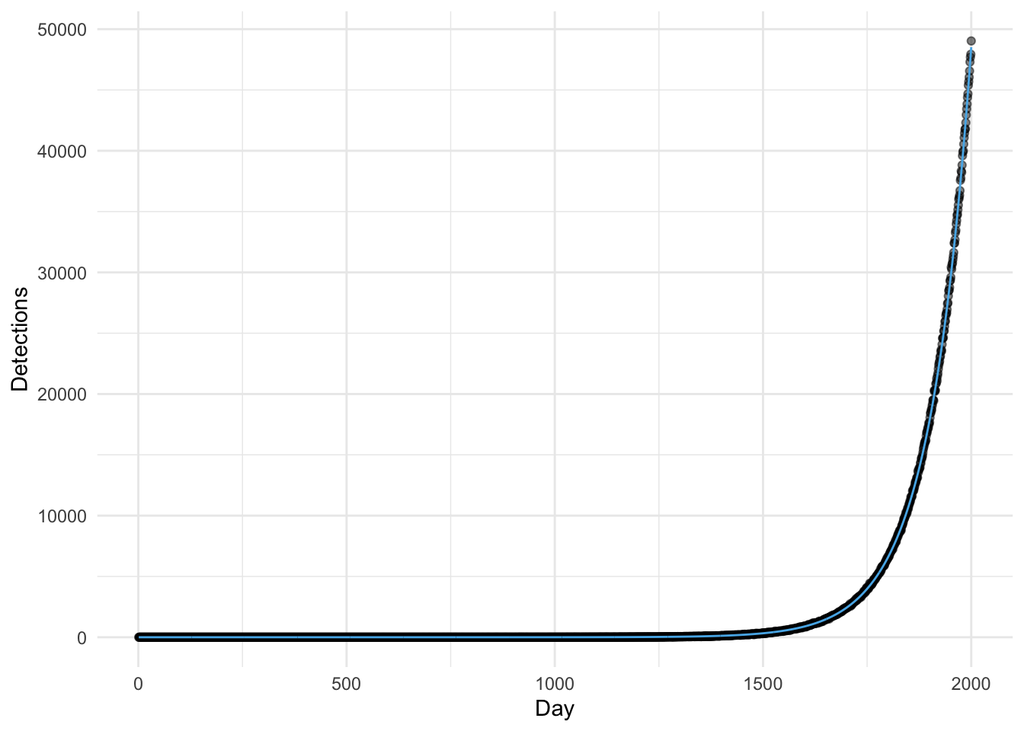

Things grow quickly after day 1500.

```r
sim %>%
  ggplot(aes(t, x)) +
  geom_point(alpha = 0.5) +
  geom_line(aes(y = lambda), color = cbpalette[1]) +
  labs(x = "Day", y = "Detections") +
  theme_minimal()
```

Let’s filter down to the early stages of the outbreak an plot the detections and confidence intervals for $\beta$.

```r
fits <- tibble(today = seq(first_detection + 1, 1000)) %>%
  mutate(
    fit = map(today, ~glm(x ~ t, family = poisson, data = sim[seq(.x),])),
    fit = map(fit, broom::tidy, conf.int = TRUE)
  ) %>%
  unnest(fit)
```

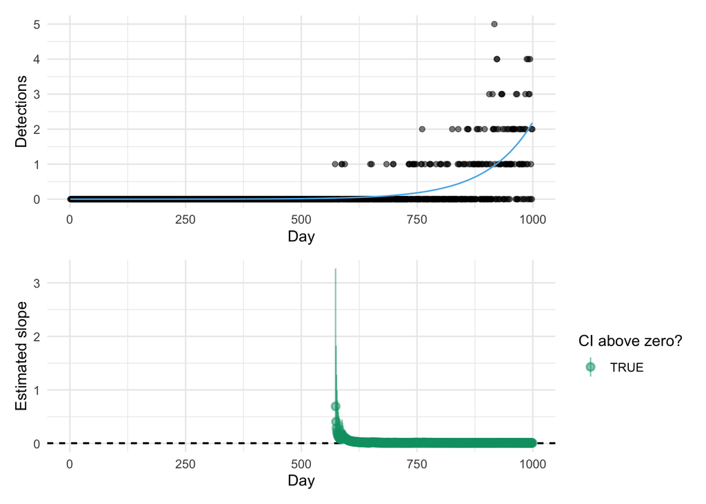

```r
p1 <- sim %>%
  filter(t < 1000) %>%
  ggplot(aes(t, x)) +
  geom_point(alpha = 0.5) +
  geom_line(aes(y = lambda), color = cbpalette[1]) +
  labs(x = "Day", y = "Detections") +
  theme_minimal()

p2 <- fits %>%
  mutate(above_zero = as.logical((conf.low > 0) & (conf.high > 0))) %>%
  filter(term == 't', today < 1e3) %>%
  ggplot(aes(today, y = estimate, ymax = conf.high, ymin = conf.low, col = above_zero)) +
  geom_hline(yintercept = c(0, r), color = "black", linetype = "dashed") +
  geom_pointrange(alpha = 0.5) +
  scale_colour_manual(values = cbpalette[c(2, 3)]) +
  expand_limits(x = 1) +
  labs(x = "Day", y = "Estimated slope", col = "CI above zero?") +
  theme_minimal()

p1 / p2
```

For this seed, after the first detection the confidence interval for $\beta$ is always above zero. In other instances, the behaviour has been more interesting (e.g. after initial detection $\beta > 0$, but $\beta = 0$ because plasuible again after a while with no detections).

As a sidenote, perhaps it’s possible to write a hotstart version of the Poisson GLM which is initialised at the previous value and would make things faster, along the lines of this (but this would be slow in R due to looping I think):

```r
hotstart_poisson_glm <- function(times) {
  out <- list()
  start_time <- times[1]
  remaining_times <- times[-1]
  fit <- glm(x ~ 1 + t, family = poisson, data = sim[1:start_time, ])
  out[[start_time]] <- fit
  for(time in remaining_times) {
    fit <- glm(x ~ 1 + t, family = poisson, data = sim[1:time, ], start = fit$coefficients)
    out[[time]] <- fit
  }
  return(out)
}
```

Let’s have a closer look at the time that the first detection starts:

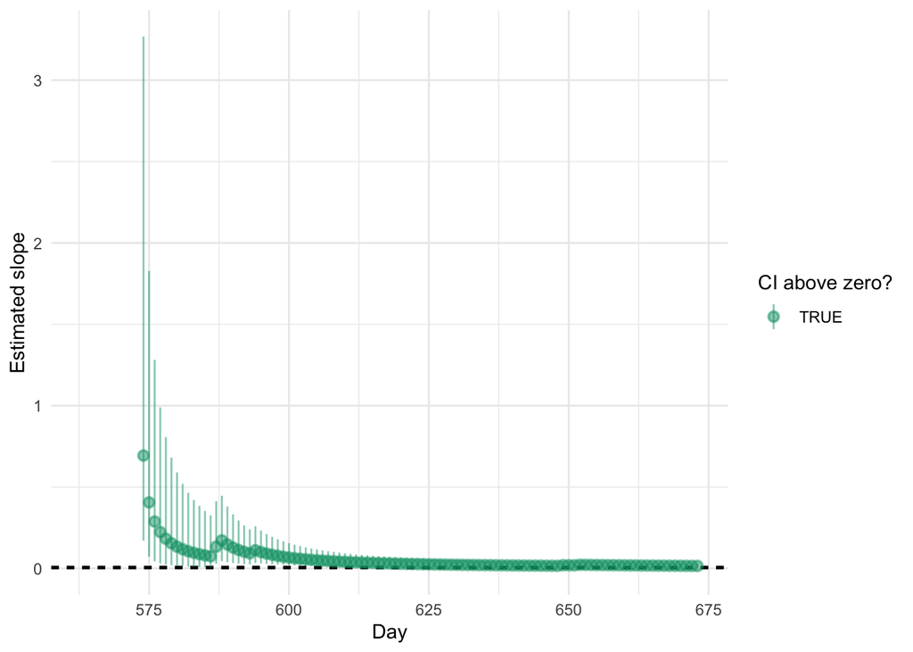

```r
p2 & xlim(c(first_detection - 10, first_detection + 100))
```

The confidence interval for the $\beta$ parameter is above zero for many days following the first detections. After detecting a single case, having not detected one for hundreds of days, it’s not really possible that there just happened to be zeros for that long, so there must be some kind of slope to the rate.

# SARS-CoV-2 simulation

We will now move on to considering a (very toy) case study. Let $T_d$ be the doubling time of a virus, which we will modelled after SARS-CoV-2 and take a doubling time of $T_d = 3$ days; which has been noted for European countries [here](https://royalsocietypublishing.org/doi/10.1098/rstb.2020.0264), though [this article](https://www.ncbi.nlm.nih.gov/pmc/articles/PMC7392464/) reports a faster doubling time for Chinese provinces, including 2.5 for Hubei province. To recover the exponential growth rate from the doubling time, calculate
$$e^{rT_d} = 2 \implies r = \log2 / T_d$$

> Note, that this [RAND article](https://www.rand.org/pubs/research_reports/RRA248-6.html) gives a 10X increase over ~1 week, which is a substantially faster doubling time (as shown by this [figure](https://www.rand.org/content/dam/rand/pubs/research_reports/RRA200/RRA248-6/RR-A248-6-log-wide.svg) in the report where the number of infected travelers was 0.1/day on Jan 22 and 1/day on Jan 29.)

```r
wuhan_tianhe_yearly <- 20000000
wuhan_tianhe_daily <- wuhan_tianhe_yearly / 365
wuhan_tianhe_daily
```

```
## [1] 54794.52
```

```r
wuhan_population <- 11000000
prob_airport <- wuhan_tianhe_daily / wuhan_population
```

```r
prob_detect <- 0.1
```

Let’s imagine that we had an environmental monitoring site set-up at Wuhan Tianhe. Suppose that each person passing through the airport with SARS-CoV-2 has a probability of being detected $p_d$ of 0.1 (note that this particular figure is not based on any particular insights). The probability of detecting a case at the airport is a product of two factors, the probability that someone someone infected uses the airport, and the probability that they’re detected, so that this case is analogous to
$$c = p_a \times p_d$$

```r
doubling_time <- 3
r <- log(2) / doubling_time
prob_detected <- 0.1

set.seed(42)

sim <- tibble(t = seq(-30, 50)) %>%
  mutate(
    lambda_total = exp(r * t),
    lambda_travel = prob_airport * lambda_total,
    lambda_detect = prob_detect * lambda_travel,
    n_total = rpois(n(), lambda_total),
    n_travel = rbinom(n(), n_total, prob = prob_airport),
    n_detect = rbinom(n(), n_travel, prob = prob_detect)
  )
```

```r
sim_long <- sim %>%
  pivot_longer(c(starts_with('n_'), starts_with('lambda_')),
    names_to = c('var', 'type'),
    names_sep = '_'
  ) %>%
  pivot_wider(names_from = var) %>%
  print
```

```
## # A tibble: 243 × 4
##        t type       n      lambda
##    <int> <chr>  <dbl>       <dbl>
##  1   -30 total      0 0.000977
##  2   -30 travel     0 0.00000486
##  3   -30 detect     0 0.000000486
##  4   -29 total      0 0.00123
##  5   -29 travel     0 0.00000613
##  6   -29 detect     0 0.000000613
##  7   -28 total      0 0.00155
##  8   -28 travel     0 0.00000772
##  9   -28 detect     0 0.000000772
## 10   -27 total      0 0.00195
## # … with 233 more rows
```

```r
first_case <- function(x) {
  sim_long %>%
    filter(
      type == x,
      n > 0
    ) %>%
    summarise(min_t = min(t)) %>%
    pull(min_t)
}

t_first_total <- first_case("total")
t_first_travel <- first_case("travel")
t_first_detect <- first_case("detect")
```

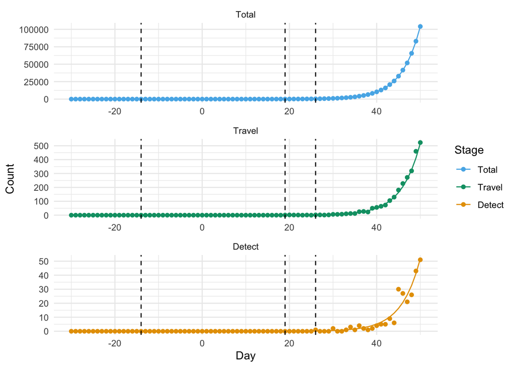

```r
p1 <- sim_long %>%
  mutate(type = dplyr::recode_factor(type, "total" = "Total", "travel" = "Travel", "detect" = "Detect")) %>%
  ggplot(aes(t, n, color = type)) +
  geom_point() +
  geom_line(aes(y = lambda)) +
  geom_vline(aes(xintercept = t_first_total), linetype = "dashed") +
  geom_vline(aes(xintercept = t_first_travel), linetype = "dashed") +
  geom_vline(aes(xintercept = t_first_detect), linetype = "dashed") +
  facet_wrap(~type, scales = "free", ncol = 1) +
  scale_colour_manual(values = cbpalette) +
  labs(x = "Day", y = "Count", col = "Stage") +
  theme(
    legend.position = "bottom"
  ) +
  theme_minimal()

p1
```

The lag in days $\ell$ between cases in the population and cases starting to pass through the airport is such that
$$p_ae^{r(t + \ell)} = e^rt \implies \ell = \log(1 / p_a) / r = T_d \log(1
/ p_a) / \log(2) = T_d \log(1 / p_d)$$
which evaluates to 22.9 days. Similarly, the lag in days between cases passing through the airport and being detected in the airport is another 10 days.

In this example, the first case occurs on day -14, the first case at the airport on day 19 and the first case to be detected on day 26.